# REHAB26-ViewAngles: data pipeline, baseline, and first experiments

Capstone Part 2. This notebook builds the data pipeline, trains a baseline MLP and a first 1D CNN, and runs two sets of experiments that each change one factor: the **feature representation** (model held fixed) and the **model** (features held fixed).

Task: given the pose sequence of one exercise repetition from one camera, predict whether it was performed correctly (0) or incorrectly (1).

Data: Jánošová, Budikova, & Sedmidubsky (2026), https://doi.org/10.5281/zenodo.23018128.

## 1. Setup

```python
import time
from pathlib import Path

import numpy as np
import pandas as pd
import matplotlib.pyplot as plt
import torch
import torch.nn as nn
from torch.utils.data import Dataset, DataLoader
from sklearn.linear_model import LogisticRegression
from sklearn.metrics import accuracy_score, f1_score, roc_auc_score

DATA = Path("../data")
FIG = Path("../docs/figures"); FIG.mkdir(parents=True, exist_ok=True)

T = 64                 # frames per repetition after resampling
TEST_PERSON = "Vasil"  # held out entirely; not used anywhere in this notebook
SEEDS = (0, 1, 2)
EPOCHS = 30
BATCH = 64
LR = 1e-3
WEIGHT_DECAY = 1e-2

device = torch.device("cuda" if torch.cuda.is_available() else "cpu")
print("PyTorch", torch.__version__, "| device:", device,
      "|", torch.cuda.get_device_name(0) if device.type == "cuda" else "")
pd.set_option("display.width", 200)
```

```
PyTorch 2.14.1+cu130 | device: cuda | NVIDIA GeForce RTX 5070 Ti Laptop GPU
```

## 2. Data pipeline

### 2.1 Load labels and slice repetitions

`Segmentation.csv` gives the first and last frame of every labeled repetition. Each repetition was recorded by three synchronized cameras, and each camera has its own MediaPipe pose array of shape `(frames, 33, 4)` (x, y, z in metres centred on the hips, plus a visibility score). One sample is one repetition seen from one camera.

Repetitions last between 1.1 and 7.5 seconds, and incorrect ones are longer on average. Every repetition is therefore linearly resampled to a fixed 64 frames. This makes batching straightforward and removes duration as a shortcut to the label.

```python
seg = pd.read_csv(DATA / "raw/Segmentation.csv", sep=";")
seg["y"] = (seg.correctness_score == 5).astype(int)          # 1 = incorrect, 0 = correct
seg["error"] = seg.error_description.fillna("correct")
seg["n_frames"] = seg.last_frame - seg.first_frame + 1
seg["rep_id"] = np.arange(len(seg))
EX_NAME = {1: "Arm abduction", 6: "Squat", 7: "Shoulder extension"}
EX_INDEX = {1: 0, 6: 1, 7: 2}
CAM_ANGLE = {1: 0, 2: 45, 3: 90}     # approximate camera positions around the participant (degrees)


def resample(seq, n):
    # Linear interpolation of a (frames, ...) array to n evenly spaced time steps.
    pos = np.linspace(0, len(seq) - 1, n)
    lo = np.floor(pos).astype(int)
    hi = np.minimum(lo + 1, len(seq) - 1)
    w = (pos - lo).reshape(-1, *[1] * (seq.ndim - 1))
    return seq[lo] * (1 - w) + seq[hi] * w


X, rows = [], []
for (vid, ex), reps in seg.groupby(["video_id", "exercise_id"]):
    for cam in (1, 2, 3):
        arr = np.load(DATA / f"mediapipe/ex{ex}/{vid}_cam{cam}_3d.npy")
        for r in reps.itertuples():
            clip = arr[r.first_frame:r.last_frame + 1]
            assert len(clip) == r.n_frames and np.abs(clip[:, :, :3]).sum(axis=(1, 2)).min() > 0
            X.append(resample(clip, T))
            rows.append(dict(rep_id=r.rep_id, person=r.person, exercise_id=ex, exercise=EX_NAME[ex], cam=cam,
                             orientation=r.person_orientation, view=CAM_ANGLE[cam] - r.person_orientation,
                             y=r.y, error=r.error, n_frames=r.n_frames))
X = np.stack(X).astype(np.float32)
meta = pd.DataFrame(rows)
P = X[..., :3]                       # joint positions, (N, T, 33, 3)
N = len(meta)
print("Pose tensor:", X.shape, "| repetitions:", meta.rep_id.nunique(), "| sequences:", N)
print("Class balance:", meta.y.value_counts().sort_index().to_dict(), "(0 = correct, 1 = incorrect)")
```

```
Pose tensor: (4995, 64, 33, 4) | repetitions: 1665 | sequences: 4995
Class balance: {0: 2496, 1: 2499} (0 = correct, 1 = incorrect)
```

### 2.2 Why coordinates need more than scaling

The 3D landmarks are centred on the hips, but their axes follow the camera. As the participant turns from 0° to 90°, the whole skeleton rotates in the coordinate system, and it also differs between the three cameras. The plot below shows the direction of the shoulder line seen from above for every sequence.

To give coordinates a fair comparison against joint angles, I add a feature set where each repetition is rotated about the vertical axis so that the participant faces the same way. The rotation is estimated once per repetition from the starting pose, so genuine torso rotation during the movement is preserved.

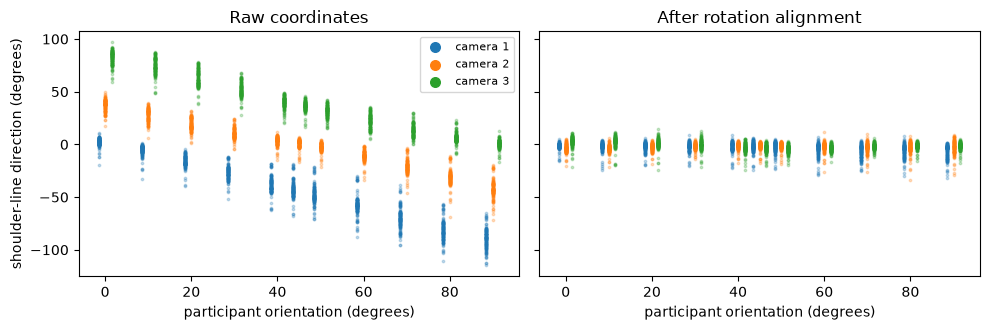

```
Spread of shoulder-line direction (std, degrees): raw 42.8, aligned 4.9
```

```python
L_SH, R_SH, L_HIP, R_HIP = 11, 12, 23, 24


def torso_length(P):
    mid_sh = (P[:, :, L_SH] + P[:, :, R_SH]) / 2
    mid_hip = (P[:, :, L_HIP] + P[:, :, R_HIP]) / 2
    return np.linalg.norm(mid_sh - mid_hip, axis=-1).mean(axis=1)        # (N,)


def scale_normalize(P):
    # Divide by the repetition's mean torso length so body size does not matter.
    return P / torso_length(P)[:, None, None, None]


def canonicalize_rotation(P, start_frac=0.1):
    # Rotate each repetition about the vertical (y) axis so the starting pose faces the camera.
    k = max(1, int(P.shape[1] * start_frac))
    d = ((P[:, :k, L_SH] - P[:, :k, R_SH]) + (P[:, :k, L_HIP] - P[:, :k, R_HIP])).mean(axis=1)
    theta = np.arctan2(d[:, 2], d[:, 0])
    c, s = np.cos(theta)[:, None, None], np.sin(theta)[:, None, None]
    out = P.copy()
    out[..., 0] = c * P[..., 0] + s * P[..., 2]
    out[..., 2] = -s * P[..., 0] + c * P[..., 2]
    return out


def shoulder_yaw(P):
    d = (P[:, :, L_SH] - P[:, :, R_SH]).mean(axis=1)
    return np.degrees(np.arctan2(d[:, 2], d[:, 0]))


P_scaled = scale_normalize(P)
P_canon = canonicalize_rotation(P_scaled)

fig, axes = plt.subplots(1, 2, figsize=(10, 3.4), sharey=True)
for ax, (arr, title) in zip(axes, [(P, "Raw coordinates"), (P_canon, "After rotation alignment")]):
    yaw = shoulder_yaw(arr)
    for cam, color in zip((1, 2, 3), ("tab:blue", "tab:orange", "tab:green")):
        m = (meta.cam == cam).values
        ax.scatter(meta.orientation[m] + (cam - 2) * 1.5, yaw[m], s=3, alpha=0.25, color=color, label=f"camera {cam}")
    ax.set_title(title); ax.set_xlabel("participant orientation (degrees)")
axes[0].set_ylabel("shoulder-line direction (degrees)")
leg = axes[0].legend(markerscale=4, fontsize=8)
for h in leg.legend_handles: h.set_alpha(1)
fig.tight_layout(); fig.savefig(FIG / "fig_p2_rotation.png", dpi=150); plt.show()
print("Spread of shoulder-line direction (std, degrees): raw %.1f, aligned %.1f"
      % (shoulder_yaw(P).std(), shoulder_yaw(P_canon).std()))
```

### 2.3 Feature sets

Four representations of the same repetitions:

| Key | Features | Size per frame |
| --- | --- | --- |
| `raw` | 3D coordinates as provided | 99 |
| `scaled` | Coordinates divided by torso length | 99 |
| `aligned` | Scaled coordinates, rotated to a common facing direction | 99 |
| `biomech` | Joint angles, segment tilts, and stance-width ratios, plus their velocities | 44 |

The biomechanical set is built from quantities a clinician would look at: elbow, shoulder, hip, knee and ankle angles; trunk lean, shoulder and hip tilt, trunk twist, head tilt; whether the arm moves in the plane of the body; knee and ankle separation relative to hip width; and foot inclination.

```python
def joint_angle(a, b, c):
    # Angle at b (degrees) between segments b->a and b->c.
    return vector_angle(a - b, c - b)


def vector_angle(u, v, unsigned_axis=False):
    cos = (u * v).sum(-1) / (np.linalg.norm(u, axis=-1) * np.linalg.norm(v, axis=-1) + 1e-9)
    if unsigned_axis:
        cos = np.abs(cos)
    return np.degrees(np.arccos(np.clip(cos, -1, 1)))


def biomech_features(P):
    J = lambda i: P[:, :, i]
    mid_sh, mid_hip = (J(11) + J(12)) / 2, (J(23) + J(24)) / 2
    trunk, sh_line, hip_line = mid_sh - mid_hip, J(11) - J(12), J(23) - J(24)
    vertical = np.array([0.0, 1.0, 0.0], dtype=P.dtype)
    hip_width = np.linalg.norm(hip_line, axis=-1) + 1e-9
    f = {
        "elbow_L": joint_angle(J(11), J(13), J(15)), "elbow_R": joint_angle(J(12), J(14), J(16)),
        "shoulder_L": joint_angle(J(23), J(11), J(13)), "shoulder_R": joint_angle(J(24), J(12), J(14)),
        "hip_L": joint_angle(J(11), J(23), J(25)), "hip_R": joint_angle(J(12), J(24), J(26)),
        "knee_L": joint_angle(J(23), J(25), J(27)), "knee_R": joint_angle(J(24), J(26), J(28)),
        "ankle_L": joint_angle(J(25), J(27), J(31)), "ankle_R": joint_angle(J(26), J(28), J(32)),
        "trunk_lean": vector_angle(trunk, vertical, unsigned_axis=True),
        "shoulder_tilt": vector_angle(sh_line, vertical),
        "hip_tilt": vector_angle(hip_line, vertical),
        "trunk_twist": vector_angle(sh_line, hip_line),
        "head_tilt": vector_angle(J(7) - J(8), sh_line),
        "neck": vector_angle(J(0) - mid_sh, trunk),
        "arm_plane_L": vector_angle(J(13) - J(11), sh_line), "arm_plane_R": vector_angle(J(14) - J(12), sh_line),
        "foot_incline_L": vector_angle(J(31) - J(29), vertical), "foot_incline_R": vector_angle(J(32) - J(30), vertical),
    }
    feats = [v / 180.0 for v in f.values()]
    names = list(f)
    feats += [np.linalg.norm(J(25) - J(26), axis=-1) / hip_width, np.linalg.norm(J(27) - J(28), axis=-1) / hip_width]
    names += ["knee_width_ratio", "ankle_width_ratio"]
    static = np.stack(feats, axis=-1)                                # (N, T, 22)
    velocity = np.gradient(static, axis=1)                           # per normalised time step
    return np.concatenate([static, velocity], axis=-1), names + [n + "_vel" for n in names]


biomech, biomech_names = biomech_features(P)
FEATURES = {
    "raw": P.reshape(N, T, -1),
    "scaled": P_scaled.reshape(N, T, -1),
    "aligned": P_canon.reshape(N, T, -1),
    "biomech": biomech.astype(np.float32),
}
FEATURE_LABEL = {"raw": "Raw 3D coordinates", "scaled": "Scaled coordinates",
                 "aligned": "Scaled + rotation-aligned coordinates", "biomech": "Biomechanical features"}
for k, v in FEATURES.items():
    assert np.isfinite(v).all()
    print(f"{k:8s} {v.shape}")


def summarize(seq):
    # Per-repetition summary statistics over time: mean, min, max, range of every feature.
    return np.concatenate([seq.mean(1), seq.min(1), seq.max(1), seq.max(1) - seq.min(1)], axis=1)
```

```
raw      (4995, 64, 99)
scaled   (4995, 64, 99)
aligned  (4995, 64, 99)
biomech  (4995, 64, 44)
```

### 2.4 Train / validation / test split

With five participants, a random split would put the same person (and the same repetition seen from another camera) on both sides and overstate performance. The split is therefore **by participant**:

- **Test:** one participant is held out completely and is not touched in this notebook. It is reserved for the final evaluation.
- **Train / validation:** the other four participants are used in a 4-fold leave-one-participant-out scheme. Each fold trains on three participants and validates on the fourth.

All three camera views of a repetition always stay in the same split. Reported validation metrics are the mean over the four folds, so every number is measured on people the model has not seen.

```python
persons = sorted(meta.person.unique())
dev_persons = [p for p in persons if p != TEST_PERSON]
test_idx = np.where(meta.person == TEST_PERSON)[0]
FOLDS = [(np.where(meta.person.isin([p for p in dev_persons if p != v]))[0], np.where(meta.person == v)[0], v)
         for v in dev_persons]

split_table = meta.groupby("person").agg(repetitions=("rep_id", "nunique"), sequences=("rep_id", "size"),
                                         incorrect_rate=("y", "mean")).round(3)
split_table["role"] = ["test (held out)" if p == TEST_PERSON else "train / validation" for p in split_table.index]
display(split_table)
for tr, va, v in FOLDS:
    assert not set(meta.person[tr]) & set(meta.person[va]) and TEST_PERSON not in set(meta.person[tr]) | set(meta.person[va])
    assert not set(meta.rep_id[tr]) & set(meta.rep_id[va])
    print(f"validate on {v:6s} train sequences {len(tr):5d}  validation sequences {len(va):5d}")
```

| person | repetitions | sequences | incorrect_rate | role |
| --- | --- | --- | --- | --- |
| Honza | 331 | 993 | 0.498 | train / validation |
| Mima | 335 | 1005 | 0.504 | train / validation |
| Petra | 331 | 993 | 0.502 | train / validation |
| Terka | 330 | 990 | 0.500 | train / validation |
| Vasil | 338 | 1014 | 0.497 | test (held out) |

```
validate on Honza  train sequences  2988  validation sequences   993
validate on Mima   train sequences  2976  validation sequences  1005
validate on Petra  train sequences  2988  validation sequences   993
validate on Terka  train sequences  2991  validation sequences   990
```

### 2.5 Batching

A small `Dataset` returns the features, a one-hot code for which exercise is being performed, and the label. Features are standardised with the mean and standard deviation of the **training fold only**. The exercise code is given to the model because the same pose can be correct for one exercise and an error for another, and the exercise is known in any real use.

```python
class RepDataset(Dataset):
    def __init__(self, x, exercise_ids, y):
        self.x = torch.as_tensor(x, dtype=torch.float32)
        self.ex = nn.functional.one_hot(torch.as_tensor([EX_INDEX[e] for e in exercise_ids]), 3).float()
        self.y = torch.as_tensor(np.asarray(y), dtype=torch.float32)

    def __len__(self):
        return len(self.y)

    def __getitem__(self, i):
        return self.x[i], self.ex[i], self.y[i]


def make_loaders(feature_key, kind, train_idx, val_idx, seed):
    seq = FEATURES[feature_key]
    if kind == "mlp":
        x = summarize(seq)                                           # (N, 4F)
        mu, sd = x[train_idx].mean(0), x[train_idx].std(0) + 1e-6
    else:
        x = seq                                                      # (N, T, F)
        mu, sd = x[train_idx].mean((0, 1)), x[train_idx].std((0, 1)) + 1e-6
    x = (x - mu) / sd
    if kind != "mlp":
        x = x.transpose(0, 2, 1)                                     # (N, F, T) for Conv1d
    ex, y = meta.exercise_id.values, meta.y.values
    g = torch.Generator().manual_seed(seed)
    train = DataLoader(RepDataset(x[train_idx], ex[train_idx], y[train_idx]), batch_size=BATCH, shuffle=True, generator=g)
    val = DataLoader(RepDataset(x[val_idx], ex[val_idx], y[val_idx]), batch_size=512, shuffle=False)
    return train, val


tr_loader, va_loader = make_loaders("aligned", "cnn", FOLDS[0][0], FOLDS[0][1], seed=0)
xb, eb, yb = next(iter(tr_loader))
print("Sequence batch:", tuple(xb.shape), tuple(eb.shape), tuple(yb.shape))
xb, eb, yb = next(iter(make_loaders("aligned", "mlp", FOLDS[0][0], FOLDS[0][1], seed=0)[0]))
print("Summary batch: ", tuple(xb.shape), tuple(eb.shape), tuple(yb.shape))
```

```
Sequence batch: (64, 99, 64) (64, 3) (64,)
Summary batch:  (64, 396) (64, 3) (64,)
```

## 3. Models

**Baseline: MLP on summary statistics.** Each repetition is reduced to the mean, minimum, maximum and range of every feature over time. The model sees how far each joint moved but not the order in which things happened.

**Advanced model (first version): 1D CNN.** Three convolutional blocks over the full 64-frame sequence, followed by global average and max pooling. This model can use the shape and timing of the movement.

Both are trained the same way: AdamW, binary cross-entropy, a fixed number of epochs. There is no early stopping on the validation fold, so the validation number is not used to pick the model it then evaluates.

```python
class MLP(nn.Module):
    def __init__(self, n_in, n_ex=3, hidden=(128, 64), dropout=0.3):
        super().__init__()
        layers, d = [], n_in + n_ex
        for h in hidden:
            layers += [nn.Linear(d, h), nn.ReLU(), nn.Dropout(dropout)]
            d = h
        self.net = nn.Sequential(*layers, nn.Linear(d, 1))

    def forward(self, x, ex):
        return self.net(torch.cat([x, ex], dim=1)).squeeze(1)


class CNN1D(nn.Module):
    def __init__(self, n_feat, n_ex=3, widths=(64, 128, 128), kernel=5, dropout=0.3):
        super().__init__()
        blocks, d = [], n_feat
        for i, w in enumerate(widths):
            blocks += [nn.Conv1d(d, w, kernel, padding=kernel // 2), nn.BatchNorm1d(w), nn.ReLU()]
            if i < len(widths) - 1:
                blocks.append(nn.MaxPool1d(2))
            d = w
        self.features = nn.Sequential(*blocks)
        self.head = nn.Sequential(nn.Dropout(dropout), nn.Linear(2 * d + n_ex, 64), nn.ReLU(),
                                  nn.Dropout(dropout), nn.Linear(64, 1))

    def forward(self, x, ex):
        h = self.features(x)
        h = torch.cat([h.mean(dim=2), h.amax(dim=2), ex], dim=1)
        return self.head(h).squeeze(1)


def build_model(kind, feature_key):
    n_feat = FEATURES[feature_key].shape[2]
    return MLP(4 * n_feat) if kind == "mlp" else CNN1D(n_feat)


for kind in ("mlp", "cnn"):
    for key in ("aligned", "biomech"):
        n = sum(p.numel() for p in build_model(kind, key).parameters())
        print(f"{kind.upper():4s} on {key:8s}: {n:,} parameters")
```

```
MLP  on aligned : 59,521 parameters
MLP  on biomech : 31,361 parameters
CNN  on aligned : 172,225 parameters
CNN  on biomech : 154,625 parameters
```

```python
def train_model(kind, feature_key, train_idx, val_idx, seed):
    # Train one model on one fold. Returns per-epoch history and final validation probabilities.
    torch.manual_seed(seed); np.random.seed(seed)
    train_loader, val_loader = make_loaders(feature_key, kind, train_idx, val_idx, seed)
    model = build_model(kind, feature_key).to(device)
    opt = torch.optim.AdamW(model.parameters(), lr=LR, weight_decay=WEIGHT_DECAY)
    loss_fn = nn.BCEWithLogitsLoss()
    y_val = meta.y.values[val_idx]
    history = []
    for epoch in range(EPOCHS):
        model.train()
        total, count = 0.0, 0
        for x, ex, y in train_loader:
            x, ex, y = x.to(device), ex.to(device), y.to(device)
            opt.zero_grad()
            loss = loss_fn(model(x, ex), y)
            loss.backward(); opt.step()
            total += loss.item() * len(y); count += len(y)
        model.eval()
        with torch.no_grad():
            logits = torch.cat([model(x.to(device), ex.to(device)) for x, ex, _ in val_loader]).cpu()
        prob = torch.sigmoid(logits).numpy()
        history.append(dict(epoch=epoch + 1, train_loss=total / count,
                            val_loss=loss_fn(logits, torch.as_tensor(y_val, dtype=torch.float32)).item(),
                            val_acc=accuracy_score(y_val, prob > 0.5)))
    return pd.DataFrame(history), prob


def run_condition(name, kind, feature_key):
    # 4 folds x 3 seeds for one (model, features) condition.
    t0 = time.time()
    scores, preds, hists = [], [], []
    for seed in SEEDS:
        for train_idx, val_idx, val_person in FOLDS:
            hist, prob = train_model(kind, feature_key, train_idx, val_idx, seed)
            y = meta.y.values[val_idx]
            scores.append(dict(condition=name, seed=seed, val_person=val_person, acc=accuracy_score(y, prob > 0.5),
                               f1=f1_score(y, prob > 0.5), auc=roc_auc_score(y, prob)))
            preds.append(meta.iloc[val_idx].assign(condition=name, seed=seed, prob=prob, pred=(prob > 0.5).astype(int)))
            hists.append(hist.assign(condition=name, seed=seed, val_person=val_person))
    scores = pd.DataFrame(scores)
    print(f"{name:34s} val acc {scores.acc.mean():.3f}  ({time.time() - t0:.0f}s)")
    return scores, pd.concat(preds), pd.concat(hists)
```

## 4. Sanity check: how much does duration give away?

Part 1 found that incorrect repetitions are longer on average. Before training anything, this is how well a logistic regression does using **only the original length of the repetition** and which exercise it is. Resampling to a fixed length removes this information from every model below, so their scores have to come from the movement itself.

```python
def duration_features(idx):
    d = meta.n_frames.values[idx, None] / 100.0
    onehot = np.eye(3)[[EX_INDEX[e] for e in meta.exercise_id.values[idx]]]
    return np.concatenate([onehot, onehot * d], axis=1)

dur = []
for train_idx, val_idx, v in FOLDS:
    clf = LogisticRegression(max_iter=1000).fit(duration_features(train_idx), meta.y.values[train_idx])
    dur.append(accuracy_score(meta.y.values[val_idx], clf.predict(duration_features(val_idx))))
print("Duration-only validation accuracy: %.3f ± %.3f (chance = 0.500)" % (np.mean(dur), np.std(dur)))
```

```
Duration-only validation accuracy: 0.536 ± 0.032 (chance = 0.500)
```

## 5. Experiments

Eight conditions: two models on four feature sets. Reading across feature sets with the model fixed is Experiment 1; reading across models with the features fixed is Experiment 2. Every condition is trained on the same four folds with three random seeds.

```python
CONDITIONS = [(f"{kind.upper()} | {key}", kind, key) for kind in ("mlp", "cnn")
              for key in ("raw", "scaled", "aligned", "biomech")]
all_scores, all_preds, all_hists = [], [], []
for name, kind, key in CONDITIONS:
    s, p, h = run_condition(name, kind, key)
    all_scores.append(s); all_preds.append(p); all_hists.append(h)
scores, preds, hists = pd.concat(all_scores), pd.concat(all_preds), pd.concat(all_hists)
ORDER = [c[0] for c in CONDITIONS]
```

```
MLP | raw                          val acc 0.715  (22s)
```

```
MLP | scaled                       val acc 0.706  (20s)
```

```
MLP | aligned                      val acc 0.717  (20s)
```

```
MLP | biomech                      val acc 0.718  (20s)
```

```
CNN | raw                          val acc 0.739  (38s)
```

```
CNN | scaled                       val acc 0.736  (39s)
```

```
CNN | aligned                      val acc 0.708  (38s)
```

```
CNN | biomech                      val acc 0.739  (34s)
```

### 5.1 Results

Validation metrics are averaged over the four held-out participants and three seeds. `acc_std_folds` is the spread across participants (after averaging seeds) and `acc_std_seeds` is the spread across seeds (after averaging participants). A difference between two conditions that is smaller than the seed spread is noise.

```python
by_fold = scores.groupby(["condition", "val_person"]).acc.mean().unstack()
by_seed = scores.groupby(["condition", "seed"]).acc.mean().unstack()
results = pd.DataFrame({
    "model": [c.split(" | ")[0] for c in ORDER],
    "features": [FEATURE_LABEL[c.split(" | ")[1]] for c in ORDER],
    "val_acc": scores.groupby("condition").acc.mean().reindex(ORDER).values,
    "acc_std_folds": by_fold.std(axis=1).reindex(ORDER).values,
    "acc_std_seeds": by_seed.std(axis=1).reindex(ORDER).values,
    "val_f1": scores.groupby("condition").f1.mean().reindex(ORDER).values,
    "val_auc": scores.groupby("condition").auc.mean().reindex(ORDER).values,
}, index=ORDER)
results.to_csv("../docs/part2_results.csv")
display(results.round(3))
print("Validation accuracy per held-out participant:")
display(by_fold.reindex(ORDER).round(3))
```

|  | model | features | val_acc | acc_std_folds | acc_std_seeds | val_f1 | val_auc |
| --- | --- | --- | --- | --- | --- | --- | --- |
| MLP \| raw | MLP | Raw 3D coordinates | 0.715 | 0.067 | 0.004 | 0.741 | 0.837 |
| MLP \| scaled | MLP | Scaled coordinates | 0.706 | 0.064 | 0.005 | 0.734 | 0.824 |
| MLP \| aligned | MLP | Scaled + rotation-aligned coordinates | 0.717 | 0.052 | 0.013 | 0.739 | 0.835 |
| MLP \| biomech | MLP | Biomechanical features | 0.718 | 0.058 | 0.006 | 0.741 | 0.811 |
| CNN \| raw | CNN | Raw 3D coordinates | 0.739 | 0.075 | 0.007 | 0.765 | 0.850 |
| CNN \| scaled | CNN | Scaled coordinates | 0.736 | 0.083 | 0.013 | 0.763 | 0.847 |
| CNN \| aligned | CNN | Scaled + rotation-aligned coordinates | 0.708 | 0.062 | 0.004 | 0.743 | 0.820 |
| CNN \| biomech | CNN | Biomechanical features | 0.739 | 0.066 | 0.005 | 0.765 | 0.840 |

```
Validation accuracy per held-out participant:
```

| val_person condition | Honza | Mima | Petra | Terka |
| --- | --- | --- | --- | --- |
| MLP \| raw | 0.640 | 0.749 | 0.790 | 0.680 |
| MLP \| scaled | 0.632 | 0.740 | 0.775 | 0.679 |
| MLP \| aligned | 0.659 | 0.740 | 0.777 | 0.694 |
| MLP \| biomech | 0.679 | 0.741 | 0.788 | 0.663 |
| CNN \| raw | 0.657 | 0.781 | 0.821 | 0.698 |
| CNN \| scaled | 0.665 | 0.784 | 0.829 | 0.666 |
| CNN \| aligned | 0.651 | 0.745 | 0.776 | 0.659 |
| CNN \| biomech | 0.682 | 0.755 | 0.826 | 0.693 |

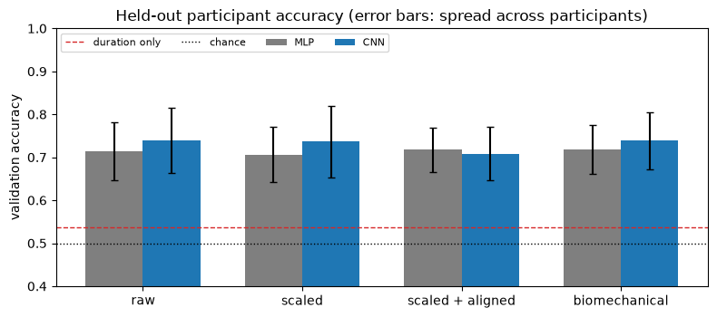

```python
fig, ax = plt.subplots(figsize=(8, 3.6))
keys = ["raw", "scaled", "aligned", "biomech"]
xpos = np.arange(len(keys))
for off, kind, color in [(-0.18, "MLP", "tab:gray"), (0.18, "CNN", "tab:blue")]:
    rows = results.loc[[f"{kind} | {k}" for k in keys]]
    ax.bar(xpos + off, rows.val_acc, 0.36, yerr=rows.acc_std_folds, capsize=3, color=color, label=kind)
ax.axhline(np.mean(dur), color="tab:red", ls="--", lw=1, label="duration only")
ax.axhline(0.5, color="black", ls=":", lw=1, label="chance")
ax.set_xticks(xpos); ax.set_xticklabels(["raw", "scaled", "scaled + aligned", "biomechanical"])
ax.set_ylabel("validation accuracy"); ax.set_ylim(0.4, 1.0); ax.legend(fontsize=8, ncol=4, loc="upper left")
ax.set_title("Held-out participant accuracy (error bars: spread across participants)")
fig.tight_layout(); fig.savefig(FIG / "fig_p2_results.png", dpi=150); plt.show()
```

### 5.2 Training curves

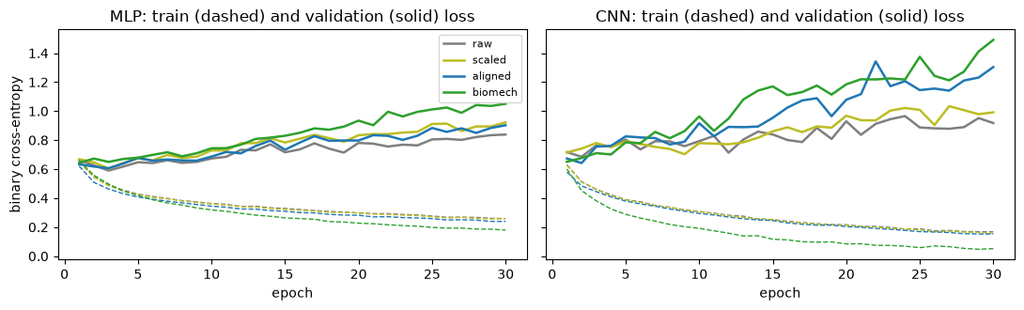

| condition | train_loss | val_loss | val_acc |
| --- | --- | --- | --- |
| MLP \| raw | 0.259 | 0.839 | 0.715 |
| MLP \| scaled | 0.259 | 0.922 | 0.706 |
| MLP \| aligned | 0.239 | 0.903 | 0.717 |
| MLP \| biomech | 0.180 | 1.051 | 0.718 |
| CNN \| raw | 0.168 | 0.918 | 0.739 |
| CNN \| scaled | 0.157 | 0.991 | 0.736 |
| CNN \| aligned | 0.152 | 1.304 | 0.708 |
| CNN \| biomech | 0.052 | 1.491 | 0.739 |

```python
curve = hists.groupby(["condition", "epoch"])[["train_loss", "val_loss", "val_acc"]].mean()
fig, axes = plt.subplots(1, 2, figsize=(11, 3.4), sharey=True)
for ax, kind in zip(axes, ("MLP", "CNN")):
    for key, color in zip(keys, ("tab:gray", "tab:olive", "tab:blue", "tab:green")):
        c = curve.loc[f"{kind} | {key}"]
        ax.plot(c.index, c.train_loss, color=color, ls="--", lw=1)
        ax.plot(c.index, c.val_loss, color=color, lw=1.8, label=key)
    ax.set_title(f"{kind}: train (dashed) and validation (solid) loss"); ax.set_xlabel("epoch")
axes[0].set_ylabel("binary cross-entropy"); axes[0].legend(fontsize=8)
fig.tight_layout(); fig.savefig(FIG / "fig_p2_curves.png", dpi=150); plt.show()
display(curve.groupby("condition").tail(1).reset_index("epoch", drop=True).reindex(ORDER).round(3))
```

### 5.3 Where the models succeed and fail

The same validation predictions, broken down three ways: by exercise, by viewing angle, and by error type. The viewing angle is the camera position minus the participant's orientation, so 0° is a frontal view and ±90° is a side view. The exercising arm is the right one. At positive angles it is on the side nearer the camera; at negative angles it is on the far side and partly hidden by the body (its mean visibility score falls to about 0.5 at the most negative angles).

| exercise condition | Arm abduction | Shoulder extension | Squat |
| --- | --- | --- | --- |
| MLP \| raw | 0.606 | 0.752 | 0.787 |
| MLP \| scaled | 0.595 | 0.761 | 0.764 |
| MLP \| aligned | 0.617 | 0.748 | 0.787 |
| MLP \| biomech | 0.642 | 0.764 | 0.748 |
| CNN \| raw | 0.650 | 0.794 | 0.774 |
| CNN \| scaled | 0.661 | 0.787 | 0.762 |
| CNN \| aligned | 0.653 | 0.781 | 0.690 |
| CNN \| biomech | 0.674 | 0.797 | 0.746 |

| view_bin condition | -90 to -61 | -60 to -31 | -30 to -1 | 0 to 30 | 31 to 60 | 61 to 90 |
| --- | --- | --- | --- | --- | --- | --- |
| MLP \| raw | 0.692 | 0.722 | 0.703 | 0.709 | 0.739 | 0.725 |
| MLP \| scaled | 0.668 | 0.705 | 0.695 | 0.700 | 0.740 | 0.733 |
| MLP \| aligned | 0.674 | 0.724 | 0.705 | 0.718 | 0.737 | 0.743 |
| MLP \| biomech | 0.665 | 0.713 | 0.704 | 0.725 | 0.754 | 0.732 |
| CNN \| raw | 0.683 | 0.754 | 0.716 | 0.748 | 0.758 | 0.762 |
| CNN \| scaled | 0.677 | 0.760 | 0.714 | 0.754 | 0.751 | 0.724 |
| CNN \| aligned | 0.634 | 0.707 | 0.688 | 0.709 | 0.758 | 0.738 |
| CNN \| biomech | 0.676 | 0.749 | 0.714 | 0.758 | 0.770 | 0.727 |

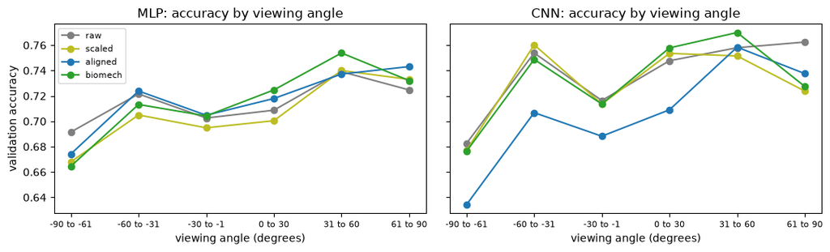

```python
preds["correct_pred"] = (preds.pred == preds.y).astype(float)
display(preds.groupby(["condition", "exercise"]).correct_pred.mean().unstack().reindex(ORDER).round(3))

preds["view_bin"] = pd.cut(preds["view"], [-91, -60, -30, -1, 30, 60, 91],
                           labels=["-90 to -61", "-60 to -31", "-30 to -1", "0 to 30", "31 to 60", "61 to 90"])
by_view = preds.groupby(["condition", "view_bin"], observed=True).correct_pred.mean().unstack().reindex(ORDER)
display(by_view.round(3))

fig, axes = plt.subplots(1, 2, figsize=(11, 3.4), sharey=True)
for ax, kind in zip(axes, ("MLP", "CNN")):
    for key, color in zip(keys, ("tab:gray", "tab:olive", "tab:blue", "tab:green")):
        ax.plot(by_view.columns.astype(str), by_view.loc[f"{kind} | {key}"], "o-", color=color, label=key)
    ax.set_title(f"{kind}: accuracy by viewing angle"); ax.set_xlabel("viewing angle (degrees)")
    ax.tick_params(axis="x", labelsize=8)
axes[0].set_ylabel("validation accuracy"); axes[0].legend(fontsize=8)
fig.tight_layout(); fig.savefig(FIG / "fig_p2_view.png", dpi=150); plt.show()
```

```python
# Recall per error type: the share of repetitions with that error that were flagged as incorrect.
# The "correct" row is the share of correct repetitions that were (rightly) not flagged.
show = ["MLP | raw", "MLP | aligned", "MLP | biomech", "CNN | aligned", "CNN | biomech"]
inc = preds[preds.y == 1].groupby(["exercise", "error", "condition"]).pred.mean().unstack()[show]
cor = preds[preds.y == 0].groupby(["exercise", "error", "condition"]).pred.apply(lambda s: 1 - s.mean()).unstack()[show]
per_error = pd.concat([cor, inc]).sort_index()
display(per_error.round(2).style.background_gradient(cmap="RdYlGn", vmin=0.3, vmax=1.0, axis=None).format("{:.2f}"))
```

| exercise | condition error | MLP \| raw | MLP \| aligned | MLP \| biomech | CNN \| aligned | CNN \| biomech |
| --- | --- | --- | --- | --- | --- | --- |
| Arm abduction | ERR_ARM_FORWARD | 0.75 | 0.79 | 0.69 | 0.81 | 0.77 |
|  | ERR_BENT_ARM | 0.50 | 0.60 | 0.73 | 0.74 | 0.81 |
|  | ERR_ELEVATED_SHOULDER | 0.65 | 0.63 | 0.63 | 0.81 | 0.79 |
|  | ERR_HEAD_TO_SIDE | 0.70 | 0.67 | 0.75 | 0.70 | 0.81 |
|  | ERR_LOW_ABDUCTION | 0.78 | 0.77 | 0.83 | 0.89 | 0.86 |
|  | correct | 0.54 | 0.54 | 0.56 | 0.52 | 0.54 |
| Shoulder extension | ERR_ARM_TO_SIDE | 0.68 | 0.62 | 0.56 | 0.58 | 0.64 |
|  | ERR_BENT_ARM | 0.76 | 0.71 | 0.70 | 0.70 | 0.69 |
|  | ERR_ELEVATED_SHOULDER | 0.82 | 0.76 | 0.84 | 0.77 | 0.80 |
|  | ERR_TORSO_FORWARD | 0.98 | 0.96 | 0.90 | 0.99 | 0.96 |
|  | ERR_TORSO_ROTATION | 0.96 | 0.95 | 0.95 | 0.95 | 0.96 |
|  | correct | 0.67 | 0.70 | 0.74 | 0.77 | 0.79 |
| Squat | ERR_KNEES_FORWARD | 0.98 | 1.00 | 0.97 | 0.99 | 0.98 |
|  | ERR_KNEES_INSIDE | 0.78 | 0.78 | 0.85 | 0.86 | 0.83 |
|  | ERR_LIFTED_HEELS | 0.98 | 1.00 | 0.96 | 0.98 | 0.97 |
|  | ERR_SHALLOW_SQUAT | 0.95 | 0.92 | 0.88 | 0.95 | 0.94 |
|  | ERR_TORSO_TO_SIDE | 0.88 | 0.86 | 0.79 | 0.86 | 0.76 |
|  | correct | 0.66 | 0.66 | 0.61 | 0.45 | 0.59 |

### 5.4 Diagnostic: seen versus unseen participants

Training loss is far below validation loss in every condition. To see whether that gap comes from the models failing to learn the task or from failing to transfer to a new person, the same models are trained on a split that mixes participants: a random 25% of repetitions from the four development participants is held out (all three views of a repetition together), so the validation set contains people the model has seen. This is **not** a valid estimate of real performance. It is only a ceiling to compare against.

```python
dev_reps = meta.rep_id[meta.person != TEST_PERSON].unique()
held = set(np.random.default_rng(0).permutation(dev_reps)[:len(dev_reps) // 4])
seen_val = np.where(meta.rep_id.isin(held))[0]
seen_train = np.where((meta.person != TEST_PERSON) & ~meta.rep_id.isin(held))[0]

seen = {}
for name, kind, key in CONDITIONS:
    accs = [train_model(kind, key, seen_train, seen_val, seed)[0].val_acc.iloc[-1] for seed in SEEDS]
    seen[name] = np.mean(accs)
gap = pd.DataFrame({"seen_participants": pd.Series(seen), "unseen_participant": results.val_acc})
gap["gap"] = gap.seen_participants - gap.unseen_participant
display(gap.round(3))

# Which kind of mistake dominates on unseen participants?
rates = preds.groupby("condition").apply(lambda d: pd.Series({
    "errors_caught (recall)": d.pred[d.y == 1].mean(),
    "correct_reps_passed (specificity)": 1 - d.pred[d.y == 0].mean()}), include_groups=False).reindex(ORDER)
display(rates.round(3))
```

|  | seen_participants | unseen_participant | gap |
| --- | --- | --- | --- |
| MLP \| raw | 0.865 | 0.715 | 0.150 |
| MLP \| scaled | 0.863 | 0.706 | 0.157 |
| MLP \| aligned | 0.870 | 0.717 | 0.152 |
| MLP \| biomech | 0.855 | 0.718 | 0.137 |
| CNN \| raw | 0.901 | 0.739 | 0.162 |
| CNN \| scaled | 0.905 | 0.736 | 0.169 |
| CNN \| aligned | 0.903 | 0.708 | 0.195 |
| CNN \| biomech | 0.892 | 0.739 | 0.153 |

| condition | errors_caught (recall) | correct_reps_passed (specificity) |
| --- | --- | --- |
| MLP \| raw | 0.810 | 0.620 |
| MLP \| scaled | 0.807 | 0.605 |
| MLP \| aligned | 0.800 | 0.635 |
| MLP \| biomech | 0.801 | 0.635 |
| CNN \| raw | 0.839 | 0.639 |
| CNN \| scaled | 0.835 | 0.637 |
| CNN \| aligned | 0.838 | 0.577 |
| CNN \| biomech | 0.838 | 0.640 |

### 5.5 Draft of the advanced model: bidirectional GRU with attention

The 1D CNN is only a first step beyond the baseline. The model I intend to develop as the advanced architecture is a **bidirectional GRU with attention pooling**. The GRU reads the repetition forwards and backwards, and the attention layer learns which moments of the movement matter most for the decision, which should also make the model's mistakes easier to inspect.

This is a rough draft. It is run here with default settings, one seed, and two feature sets, and it is **not** part of the results table. Still to do: tuning, more seeds, the remaining feature sets, visibility scores as an extra input, augmentation, and looking at where the attention weights fall.

```python
class BiGRUAttention(nn.Module):
    def __init__(self, n_feat, n_ex=3, hidden=64, layers=2, dropout=0.3):
        super().__init__()
        self.proj = nn.Sequential(nn.Linear(n_feat, hidden), nn.ReLU(), nn.Dropout(dropout))
        self.gru = nn.GRU(hidden, hidden, num_layers=layers, batch_first=True, bidirectional=True, dropout=dropout)
        self.attn = nn.Sequential(nn.Linear(2 * hidden, 64), nn.Tanh(), nn.Linear(64, 1))
        self.head = nn.Sequential(nn.Dropout(dropout), nn.Linear(2 * hidden + n_ex, 64), nn.ReLU(),
                                  nn.Dropout(dropout), nn.Linear(64, 1))

    def forward(self, x, ex, return_attention=False):
        h, _ = self.gru(self.proj(x.transpose(1, 2)))            # (N, T, 2 * hidden)
        w = torch.softmax(self.attn(h).squeeze(-1), dim=1)       # (N, T) attention over time
        pooled = (h * w.unsqueeze(-1)).sum(dim=1)
        out = self.head(torch.cat([pooled, ex], dim=1)).squeeze(1)
        return (out, w) if return_attention else out


_build_baseline_model = build_model

def build_model(kind, feature_key):
    if kind == "bigru":
        return BiGRUAttention(FEATURES[feature_key].shape[2])
    return _build_baseline_model(kind, feature_key)


# Shape check on one batch
xb, eb, yb = next(iter(make_loaders("biomech", "bigru", FOLDS[0][0], FOLDS[0][1], seed=0)[0]))
model = build_model("bigru", "biomech")
logits, attention = model(xb, eb, return_attention=True)
print("input", tuple(xb.shape), "-> logits", tuple(logits.shape), "| attention", tuple(attention.shape),
      "| parameters: {:,}".format(sum(p.numel() for p in model.parameters())))

# Preliminary run: same folds and training settings as the other models, one seed only
draft = []
for key in ("raw", "biomech"):
    for train_idx, val_idx, person in FOLDS:
        hist, _ = train_model("bigru", key, train_idx, val_idx, seed=0)
        last = hist.iloc[-1]
        draft.append(dict(features=key, val_person=person, val_acc=last.val_acc,
                          train_loss=last.train_loss, val_loss=last.val_loss))
draft = pd.DataFrame(draft)
table = draft.pivot(index="features", columns="val_person", values="val_acc")
table["mean"] = table.mean(axis=1)
print("\nBiGRU + attention, validation accuracy per held-out participant (seed 0):")
print(table.round(3).to_string())
print("\nFinal losses (mean over folds):")
print(draft.groupby("features")[["train_loss", "val_loss"]].mean().round(3).to_string())
```

```
input (64, 44, 64) -> logits (64,) | attention (64, 64) | parameters: 144,130

BiGRU + attention, validation accuracy per held-out participant (seed 0):
val_person  Honza   Mima  Petra  Terka   mean
features
biomech     0.647  0.746  0.782  0.690  0.716
raw         0.704  0.707  0.802  0.692  0.726

Final losses (mean over folds):
          train_loss  val_loss
features
biomech        0.151     1.151
raw            0.181     1.043
```

## 6. Results table and progress summary

**Table 1**

*Preliminary results: mean validation accuracy over four held-out participants and three seeds, ± the spread across participants*

[output not shown]

Experiment 1 changes only the features (model fixed to the MLP). Experiment 2 changes only the model (each CNN row is compared with the MLP row that uses the same features). Seed-to-seed variation is about 0.01, and repeated runs of the CNN differ by about the same amount.

### What is working

- **The data pipeline.** Repetitions are sliced, resampled to a fixed length, converted into four feature sets, split by participant, standardized on training data only, and batched. One participant is held out as a test set and has not been touched.
- **Both models train.** The MLP baseline and a first 1D CNN run on every feature set, and all eight conditions beat chance and the duration-only check by a wide margin.
- **The experiments isolate one factor each**, and the per-exercise, per-view and per-error breakdowns come from the same validation predictions.

### What the results say so far

- **Generalizing to a new person is the main problem.** Accuracy is 0.71 to 0.74 on an unseen participant but 0.86 to 0.91 when the participant was seen during training. That 14 to 20 point gap is far larger than any difference between feature sets or models.
- **The mistakes are mostly false alarms.** The models catch 80 to 84% of incorrect repetitions but pass only 58 to 64% of correct ones. A new person's normal way of moving is often read as an error. Arm abduction is the hardest exercise (0.60 to 0.67), where barely half of correct repetitions pass.
- **Feature representation made no measurable difference.** The four feature sets are within about one point of each other under the MLP. Rotation alignment did what it was designed to do but did not help.
- **Viewpoint matters, and no feature set fixes it.** Accuracy is lowest (0.63 to 0.69) when the exercising arm is on the far side of the body from the camera, where MediaPipe's confidence in that arm drops to about 0.5. Biomechanical features are no more robust here than raw coordinates.
- **The CNN is modestly better** than the MLP on three of four feature sets, by 2 to 3 points.

### What is not working

- **Overfitting.** Training loss keeps falling while validation loss rises in every condition. Nothing has been tuned and there is no augmentation yet.
- **Too little statistical power to rank feature sets.** Accuracy varies by 5 to 8 points from one held-out participant to the next, which is larger than every difference in the table. Only the CNN versus MLP comparison on raw and biomechanical features is consistent across all four participants.
- **My hypothesis is not supported so far.** I expected joint angles to transfer better across people and views than coordinates. At this stage they do not.
- **The advanced model is a rough draft.** The 1D CNN is only a first step past the baseline. I have drafted a bidirectional GRU with attention as the main advanced model. An untuned, single-seed run gives 0.72 to 0.73, no better than the CNN, and it is not in the table. The CNN's poor result on aligned coordinates is also unexplained.

### Next steps

1. Attack the person gap directly: stronger regularization, augmentation (random rotation, scaling, time warping), and features measured relative to each repetition's own starting pose.
2. Run the viewpoint experiment properly by training on some viewing angles and testing on others.
3. Develop the bidirectional GRU with attention: tune it, run it on every feature set with several seeds, give it the visibility scores, and look at where its attention falls.
4. Move to evaluation that rotates the held-out participant, so the final numbers do not depend on one person.